# Basic data selection and transformations using R

## Selecting data: Subsetting using base R

- Text
- Code
- Output
- Base R provides indexing for selecting subsets of data.
- Use `[]` for selecting rows and columns.
- Logical conditions can filter data.
- `subset()` simplifies selection based on conditions.
- Useful for quick exploratory data analysis.

```r
# Example: Subsetting a dataset
data <- mtcars[mtcars$mpg > 20, ]
head(data)
```

```r
#| echo: false
#| output: true

                    mpg cyl disp  hp drat    wt  qsec vs am gear carb
Mazda RX4         21.0   6  160 110 3.90 2.620 16.46  0  1    4    4
Mazda RX4 Wag     21.0   6  160 110 3.90 2.875 17.02  0  1    4    4
Datsun 710        22.8   4  108  93 3.85 2.320 18.61  1  1    4    1
```

## Selecting data: Using dplyr select()

- Text
- Code
- Output
- `dplyr` provides efficient data manipulation functions.
- The `select()` function chooses specific columns.
- Columns can be chosen by name or pattern.
- `rename()` can be used for renaming columns.
- `tidyverse` functions are chainable with `|>`.

```r
# Example: Selecting columns with dplyr
library(dplyr)
data <- mtcars |>
  select(mpg, cyl, hp)
head(data)
```

```r
#| echo: false
#| output: true

                    mpg cyl  hp
Mazda RX4         21.0   6 110
Mazda RX4 Wag     21.0   6 110
Datsun 710        22.8   4  93
```

## Research questions

- How does penguin `weight` vary by `species`?
- Expectation (hypothesis) about relationships
- Measurement variable (weight) by explanatory variable (species)
- Bivariate analysis, summary table with descriptive stats

| species | Count | NA_Body_Mass | Mean_Body_Mass | SD_Body_Mass | SEM_Body_Mass |
| --- | --- | --- | --- | --- | --- |
| Adelie | 152 | 1 | 3700.662 | 458.5661 | 37.19462 |
| Chinstrap | 68 | 0 | 3733.088 | 384.3351 | 46.60747 |
| Gentoo | 124 | 1 | 5076.016 | 504.1162 | 45.27097 |

## Transforming data

- e.g. scaling, log trans, centering, normalizing
- string variables, regular exp
- imputing, exptrapolating values, handling missing values
- reshaping data (basic), merging joining relational data (advanced)
- `summarizing`, grouping, aggregating etc

## Transforming data: Filtering rows

- Text
- Code
- Output
- Filtering extracts specific rows based on conditions.
- The `filter()` function from `dplyr` simplifies row selection.
- Logical conditions define which rows to keep.
- Multiple conditions can be combined using `&` or `|`.
- Useful for subsetting large datasets.

```r
library(dplyr)
data <- tibble::tibble(
  Name = c("Alice", "Bob", "Charlie"),
  Score = c(85, 90, 75)
)
filtered_data <- data |>
  filter(Score > 80)
print(filtered_data)
```

```r
#| echo: false
#| output: true

# A tibble: 2 × 2
  Name  Score
  <chr> <dbl>
1 Alice    85
2 Bob      90
```

## Transforming data: select() and filter()

- Text
- Code
- Output
- `select()` extracts specific columns.
- `filter()` selects rows based on conditions.
- Used together to refine data views.
- Helps in feature selection for modeling.
- Makes data frames more manageable.

```r
library(dplyr)
data <- tibble::tibble(
  Name = c("Alice", "Bob", "Charlie"),
  Score = c(85, 90, 75),
  Age = c(25, 30, 22)
)
selected_filtered_data <- data |>
  select(Name, Score) |>
  filter(Score > 80)
print(selected_filtered_data)
```

```r
#| echo: false
#| output: true

# A tibble: 2 × 2
  Name  Score
  <chr> <dbl>
1 Alice    85
2 Bob      90
```

## Transforming data: dplyr arrange()

- Text
- Code
- Output
- Sorting arranges data in ascending or descending order.
- The `arrange()` function in `dplyr` performs sorting.
- Use `desc()` for descending order.
- Sorting helps in ranking and comparisons.
- Can sort by multiple columns.

```r
library(dplyr)
data <- tibble::tibble(
  Name = c("Alice", "Bob", "Charlie"),
  Score = c(85, 90, 75)
)
sorted_data <- data |>
  arrange(desc(Score))
print(sorted_data)
```

```r
#| echo: false
#| output: true

# A tibble: 3 × 2
  Name    Score
  <chr>   <dbl>
1 Bob        90
2 Alice      85
3 Charlie    75
```

## Transforming data: dplyr mutate()

- Text
- Code
- Output
- `mutate()` creates new variables.
- Can modify or transform existing columns.
- Useful for feature engineering.
- Supports mathematical operations.
- Keeps original data intact while adding new fields.

```r
library(dplyr)
data <- tibble::tibble(
  Name = c("Alice", "Bob", "Charlie"),
  Score = c(85, 90, 75)
)
mutated_data <- data |>
  mutate(Grade = ifelse(Score > 80, "Pass", "Fail"))
print(mutated_data)
```

```r
#| echo: false
#| output: true

# A tibble: 3 × 3
  Name    Score Grade
  <chr>   <dbl> <chr>
1 Alice      85 Pass
2 Bob        90 Pass
3 Charlie    75 Fail
```

## Transforming data: dplyr group_by()

- Text
- Code
- Output
- `group_by()` groups data by one or more variables.
- Used with `summarize()` to compute group statistics.
- Aggregates data efficiently.
- Helps in analyzing categorical variables.
- Useful for reporting and summaries.

```r
library(dplyr)
data <- tibble::tibble(
  Group = c("A", "A", "B", "B"),
  Score = c(85, 90, 75, 80)
)
grouped_data <- data |>
  group_by(Group) |>
  summarize(Average_Score = mean(Score))
print(grouped_data)
```

```r
#| echo: false
#| output: true

# A tibble: 2 × 2
  Group Average_Score
  <chr>        <dbl>
1 A               87.5
2 B               77.5
```

## Transforming data: Aggregations

- Text
- Code
- Output
- Aggregation summarizes data using functions like `sum()`, `mean()`.
- `group_by()` in `dplyr` helps compute grouped summaries.
- Common aggregate functions include `min()`, `max()`, `sd()`.
- Aggregations are useful for statistical summaries and reporting.
- Can be applied across multiple columns.

```r
library(dplyr)
data <- tibble::tibble(
  Group = c("A", "A", "B", "B"),
  Score = c(85, 90, 75, 80)
)
agg_data <- data |>
  group_by(Group) |>
  summarize(Average_Score = mean(Score))
print(agg_data)
```

```r
#| echo: false
#| output: true

# A tibble: 2 × 2
  Group Average_Score
  <chr>        <dbl>
1 A               87.5
2 B               77.5
```

## Reshaping data

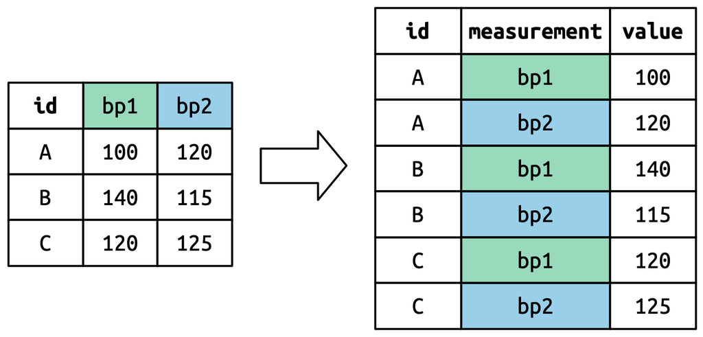

Figure 3: The column names of pivoted columns become values in a new column. The values need to be repeated once for each row of the original dataset.

## Transforming data: pivot_longer()

- Text
- Code
- Output
- `pivot_longer()` converts wide data into long format.
- Useful for making datasets tidy.
- Helps reshape data for visualization.
- Used when multiple columns represent a single variable.
- Reduces redundant column headers.

```r
library(tidyr)
data <- tibble::tibble(
  Name = c("Alice", "Bob"),
  Math = c(85, 90),
  Science = c(88, 92)
)
long_data <- data |>
  pivot_longer(
    cols = c(Math, Science),
    names_to = "Subject",
    values_to = "Score"
  )
print(long_data)
```

```r
#| echo: false
#| output: true

# A tibble: 4 × 3
  Name  Subject  Score
  <chr> <chr>    <dbl>
1 Alice Math        85
2 Alice Science     88
3 Bob   Math        90
4 Bob   Science     92
```

## Transforming data: pivot_wider()

- Text
- Code
- Output
- `pivot_wider()` converts long data into wide format.
- Useful for restructuring data for analysis.
- Spreads multiple values into separate columns.
- Helps in comparisons across categories.
- Often used for creating summary tables.

```r
library(tidyr)
long_data <- tibble::tibble(
  Name = c("Alice", "Alice", "Bob", "Bob"),
  Subject = c("Math", "Science", "Math", "Science"),
  Score = c(85, 88, 90, 92)
)
wide_data <- long_data |>
  pivot_wider(
    names_from = Subject,
    values_from = Score
  )
print(wide_data)
```

```r
#| echo: false
#| output: true

# A tibble: 2 × 3
  Name  Math Science
  <chr> <dbl>   <dbl>
1 Alice    85      88
2 Bob      90      92
```

## Transforming data: Logical vectors

- Text
- Code
- Output
- Plot
- Logical vectors store `TRUE` or `FALSE` values.
- Created using logical conditions in filtering.
- Can be used in `ifelse()` statements.
- Useful for subsetting data efficiently.
- Helps in conditional data manipulation.

```r
library(dplyr)
data <- tibble::tibble(
  Name = c("Alice", "Bob", "Charlie"),
  Score = c(85, 90, 75)
)
data <- data |>
  mutate(Pass = Score > 80)
print(data)
```

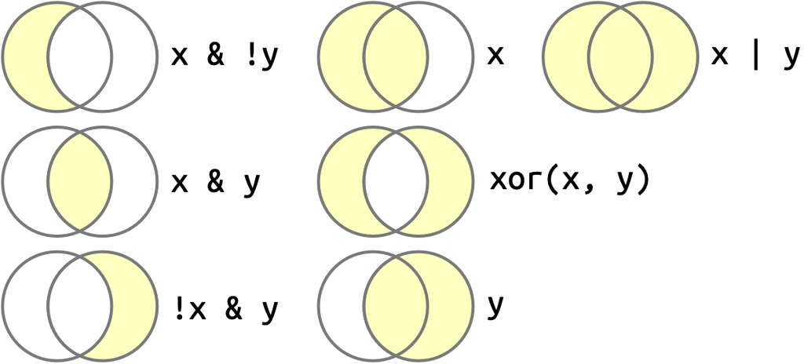

Figure 4: The complete set of Boolean operations. `x` is the left-hand circle, `y` is the right-hand circle, and the shaded regions show which parts each operator selects.

```r
#| echo: false
#| output: true

# A tibble: 3 × 3
  Name    Score Pass
  <chr>   <dbl> <lgl>
1 Alice      85 TRUE
2 Bob        90 TRUE
3 Charlie    75 FALSE
```

## Transforming data: Numbers

- Text
- Code
- Output
- Numeric transformations modify or create numerical values.
- Common functions include `log()`, `sqrt()`, and `round()`.
- Scaling and standardization are useful for modeling.
- Arithmetic operations can be applied element-wise.
- `mutate()` in `dplyr` can create new transformed columns.

```r
library(dplyr)
data <- tibble::tibble(
  Name = c("Alice", "Bob", "Charlie"),
  Score = c(85, 90, 75)
)
data <- data |>
  mutate(
    Log_Score = log(Score),
    Scaled_Score = Score / max(Score)
  )
print(data)
```

```r
#| echo: false
#| output: true

# A tibble: 3 × 4
  Name    Score Log_Score Scaled_Score
  <chr>   <dbl>     <dbl>        <dbl>
1 Alice      85      4.44        0.944
2 Bob        90      4.50        1
3 Charlie    75      4.32        0.833
```

## Transforming data: Strings

- Text
- Code
- Output
- String transformations modify text data.
- Functions like `toupper()`, `tolower()`, and `str_replace()` help clean text.
- String manipulation is useful for categorical data.
- `stringr` package provides additional tools for text handling.
- Common transformations include trimming, replacing, and extracting patterns.

```r
library(stringr)
data <- tibble::tibble(
  Name = c("Alice", "Bob", "Charlie")
)
data <- data |>
  mutate(
    Upper_Name = toupper(Name),
    Short_Name = str_sub(Name, 1, 3)
  )
print(data)
```

```r
#| echo: false
#| output: true

# A tibble: 3 × 3
  Name    Upper_Name Short_Name
  <chr>   <chr>      <chr>
1 Alice   ALICE      Ali
2 Bob     BOB        Bob
3 Charlie CHARLIE    Cha
```

## Transforming data: Regular expressions

- Text
- Code
- Output
- Regular expressions help search and manipulate patterns in text.
- `str_detect()` finds matching patterns.
- `str_replace()` replaces specific text parts.
- Useful for cleaning and extracting structured data.
- Can be used in filtering and subsetting datasets.

```r
library(stringr)
data <- tibble::tibble(
  Text = c("apple123", "banana456", "cherry789")
)
data <- data |>
  mutate(
    Extracted_Number = str_extract(Text, "\\d+")
  )
print(data)
```

```r
#| echo: false
#| output: true

# A tibble: 3 × 2
  Text       Extracted_Number
  <chr>      <chr>
1 apple123   123
2 banana456  456
3 cherry789  789
```

## Transforming data: Factors

- Text
- Code
- Output
- Factors represent categorical data in R.
- `factor()` function converts character data to categorical format.
- Ordered factors help in ranked categories.
- Factors can have predefined levels.
- Useful for statistical modeling and visualization.

```r
library(dplyr)
data <- tibble::tibble(
  Name = c("Alice", "Bob", "Charlie"),
  Grade = c("A", "B", "A")
)
data <- data |>
  mutate(
    Grade = factor(
      Grade,
      levels = c("A", "B", "C"),
      ordered = TRUE
    )
  )
print(data)
```

```r
#| echo: false
#| output: true

# A tibble: 3 × 2
  Name    Grade
  <chr>   <ord>
1 Alice   A
2 Bob     B
3 Charlie A
```

## Transforming data: Dates and times

- Text
- Code
- Output
- Dates and times are stored as special data types in R.
- The `lubridate` package simplifies date-time manipulation.
- Functions like `ymd()`, `mdy()`, and `hms()` parse dates.
- Arithmetic operations work on date-time objects.
- Useful for time-series analysis and scheduling.

```r
library(lubridate)
data <- tibble::tibble(
  Name = c("Alice", "Bob"),
  Birthdate = c("1990-05-15", "1985-10-30")
)
data <- data |>
  mutate(
    Birthdate = ymd(Birthdate),
    Age = as.numeric(Sys.Date() - Birthdate) / 365
  )
print(data)
```

```r
#| echo: false
#| output: true

# A tibble: 2 × 3
  Name  Birthdate   Age
  <chr> <date>    <dbl>
1 Alice 1990-05-15  33.9
2 Bob   1985-10-30  38.3
```

## Transforming data: Missing values

- Text
- Code
- Output
- Missing values are represented as `NA` in R.
- `is.na()` checks for missing values.
- `na.omit()` removes missing values from a dataset.
- `mutate()` with `replace_na()` fills missing values.
- Handling missing values is crucial for accurate analysis.

```r
library(dplyr)
data <- tibble::tibble(
  Name = c("Alice", "Bob", "Charlie"),
  Score = c(85, NA, 75)
)
data <- data |>
  mutate(
    Score = replace_na(Score, mean(Score, na.rm = TRUE))
  )
print(data)
```

```r
#| echo: false
#| output: true

# A tibble: 3 × 2
  Name    Score
  <chr>   <dbl>
1 Alice      85
2 Bob        80
3 Charlie    75
```

## Transforming data: Joins

- Text
- Code
- Output
- Joins combine two data frames based on a common key.
- `left_join()` keeps all rows from the first table.
- `inner_join()` keeps only matching rows.
- `full_join()` includes all rows from both tables.
- Helps merge datasets efficiently.

```r
library(dplyr)
data1 <- tibble::tibble(
  ID = c(1, 2, 3),
  Name = c("Alice", "Bob", "Charlie")
)
data2 <- tibble::tibble(
  ID = c(2, 3, 4),
  Score = c(90, 75, 88)
)
joined_data <- left_join(data1, data2, by = "ID")
print(joined_data)
```

```r
#| echo: false
#| output: true

# A tibble: 3 × 3
     ID Name    Score
  <dbl> <chr>   <dbl>
1     1 Alice      NA
2     2 Bob        90
3     3 Charlie    75
```

## Exporting data frames

- Text
- Code
- Output
- Data frames can be saved to CSV, Excel, or RDS formats.
- `write.csv()` writes a data frame to a CSV file.
- `write_rds()` saves data for use in R.
- `read_csv()` and `read_rds()` reload saved files.
- Exporting data allows sharing and persistence.

```r
library(readr)
data <- tibble::tibble(
  Name = c("Alice", "Bob", "Charlie"),
  Score = c(85, 90, 75)
)
write_csv(data, "../../csv/data.csv")
write_rds(data, "../../csv/data.rds")
```

```r
#| echo: false
#| output: true

# Files "data.csv" and "data.rds" have been created.
```

## Visualizing data

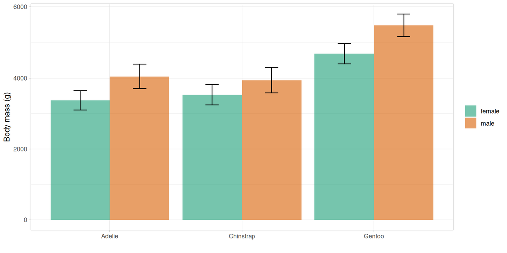

## Next steps

**Computer lab 1, feb 21**

- Link to lecture notes: https://cca-cce.github.io/osm-comm/web/edu/simp59-01tra.html

**References**

Watt, H., and T. Naidoo. 2025. “Data Wrangling Recipes in r.” https://bookdown.org/hcwatt99/Data_Wrangling_Recipes_in_R/#why-data-wrangling-recipes-in-r.

Wickham, Hadley, Mine Çetinkaya-Rundel, and Garrett Grolemund. 2023. *R for Data Science*. 2nd ed. "O’Reilly Media, Inc.". https://r4ds.hadley.nz/.

Wilke, Claus O. 2019. *Fundamentals of Data Visualization: A Primer on Making Informative and Compelling Figures*. O’Reilly Media. https://clauswilke.com/dataviz/.